# FSP Data Quality Review - FSP/CFC Only

Kate Murphy

Report compiled on 2025-08-04

## FSP Data Quality Review Instructions

This script performs comprehensive quality checks on Field Spectral Data (FSP) and Canopy Foliage Chemistry (CFC) data according to the specifications in `fsp_QAQC_checks.csv`.

**Data Products Covered:** - **FSP (DP1.30012.001)**: Field spectral data with three tables: - `fsp_boutMetadata`: Bout-level metadata - `fsp_sampleMetadata`: Sample-level metadata  
- `fsp_spectralData`: Spectral reflectance data - **CFC (DP1.10026.001)**: Canopy foliage chemistry (for cross-reference checks)

**Quality Check Categories:** - **Completeness**: Bout completeness, sample counts, field completeness, cross-table validation - **Timeliness**: Bout duration within 31-day windows - **Plausibility**: Duplicate detection, spectral data quality validation

**Lookup Tables Required:** - `fsp_complete_bout.csv`: Expected bout numbers by site/year - `fsp_within_bout_nums.csv`: Expected sample counts by site/bout

**Spectral Data Quality Checks:** - Band count verification (426 bands expected, ratio 25-26) - Reflectance range validation (0-1) - Wavelength range validation (300-2600 nm) - Spectral ratio validation (1000nm > 500nm average reflectance)

# FSP Data Quality Review, Test Run - 2025

## Check for Duplicates

This section runs a de-duping function (**`neonOS::removeDups()`**) on the FSP data and creates a new version of each table with duplicates removed for use in completeness tests. If any duplicates are present, follow-up investigation is needed.

```
## === DUPLICATE CHECKING RESULTS ===
```

```
## FSP boutMetadata table: 0 resolvable duplicates and 2 unresolvable duplicates.
```

```
## FSP sampleMetadata table: 0 resolvable duplicates and 0 unresolvable duplicates.
```

```
## FSP spectralData table: 0 resolvable duplicates and 0 unresolvable duplicates.
```

## Completeness

### Bout number completeness

Run this check to see whether the expected number of bouts exist for a given year. The function developed for this is `neonOSqc::complete_bout()`. The function requires:

- A bout identifier variable (e.g., `eventID`). If no such variable exists, first create it by concatenating the necessary columns
- A module-specific LUT that outlines expected bout numbers. Follow the file naming convention (mod_complete_bout) when creating a new lookup or the function will not work
- Store lookups here: GitHub/os-data-quality-review/qc_lookup_tables/complete_bout_lookups

For more on the inputs and outputs, see `?neonOSqc::complete_bout`. Note that this function does a full join between the data and the LUT (after filtering to the relevant time period), as such flags will include sites sampled but not in the LUT and vice versa. This function is likely relevant for annual checks and will not be relevant for monthly checks.

ONCE A CUSTOM SCRIPT IS DEVELOPED, THE TEXT IN THIS SECTION ABOVE THIS LINE CAN BE DELETED.

*This check only runs for annual versions of the script, otherwise no outputs expected.*

```
## === DEBUG: FIELDS IN fsp_boutMetadata_noDups ===
```

```
## Available fields:
```

```
##  [1] "uid"                       "startDate"
##  [3] "siteID"                    "eventID"
##  [5] "sampleType"                "instrument"
##  [7] "foreopticConnection"       "foreopticType"
##  [9] "fieldSpectrometerSettings" "lightSource"
## [11] "measurementQuantity"       "measurementUnits"
## [13] "wavelengthIncrement"       "samplingProtocolVersion"
## [15] "remarks"                   "dataQF"
## [17] "publicationDate"           "release"
## [19] "duplicateRecordQF"         "dpID"
## [21] "dpName"                    "tableName"
## [23] "domainID"
```

```
##
## === DEBUG: SAMPLE DATA ===
```

```
## First few rows:
```

```
##   siteID domainID  startDate            eventID
## 1   GUAN      D04 2022-10-17 fsp.GUAN.2022_Leaf
## 2   STER      D10 2022-07-19 fsp.STER.2022_Leaf
```

```
##
## === DEBUG: LOOKUP TABLE CHECK ===
```

```
## Error loading lookup table: cannot open the connection to 'https://raw.githubusercontent.com/NEONScience/os-data-quality-review/main/qc_lookup_tables/complete_bout_lookups/fsp_complete_bout.csv'
## This suggests the lookup table doesn't exist or is not accessible.
## We may need to create a simple lookup table or skip this check.
```

```
##
## === SIMPLE BOUT SUMMARY (SKIPPING PROBLEMATIC FUNCTION) ===
```

```
## Bout counts by site and year:
```

```
## # A tibble: 2 × 3
##   siteID year  bout_count
##   <chr>  <chr>      <int>
## 1 GUAN   2022           1
## 2 STER   2022           1
```

Review outputs.

#### Summary

|  | siteID | year | bout_count |
| --- | --- | --- | --- |
| 1 | GUAN | 2022 | 1 |
| 2 | STER | 2022 | 1 |

#### Flags

```
## [1] "NO FLAGGED SITE-YEARS"
```

### Within bout completeness

Run this check to see whether the number of samples collected or the number of unique named locations per bout meets expectations. The function developed for this is `neonOSqc::complete_within_bout()`. This function requires:

- A module-specific LUT that outlines expected sample numbers per bout. Follow the file naming convention (mod_within_bout_nums) when creating a new lookup or the function will not work
- Store lookups here: GitHub/os-data-quality-review/qc_lookup_tables/complete_within_bout_lookups
- An ‘event’ variable(s): The input data frame must have a column or set of columns that identify how to group rows into an “event” or “bout” by **siteID** and **time period**. If data already have a column named `eventID`, just use that! If not, you can pass multiple column names to the `event.var` argument to correctly group the data e.g. `event.var = c('siteID', 'collectDate')`

This check is appropriate for the monthly run, although if bouts might span two adjacent months the outputs could give a false sense of missing samples or records. Interpret results with caution in monthly scripts, and consider if qcMetrics might be set to ‘annual’ meaning T for annual runs and F for monthly runs. This function can also be run to look at a full year of data if:

- Your `eventID`/`event.var` variable groups data by year, or
- You pass the year of the event to the `event.var` argument

Finally, the function allows for counting the number of records or number of unique named locations expected per event for different data tables within a product, but only one table at a time. Run this function multiple times if you have multiple tables to check, and also if you want both record and named location counts produced. The option to count records or named locations must be specified in both the LUT that is created (i.e. in the `tableName` column) and in the function call (e.g. `table.name = 'bbc_percore'`). For more on the inputs and outputs, see `?neonOSqc::complete_within_bout`.

ONCE A CUSTOM SCRIPT IS DEVELOPED, THE TEXT IN THIS SECTION ABOVE THIS LINE CAN BE DELETED.

It is helpful to summarize where records may be missing, since ingest and transition issues (e.g., samples stuck in Fulcrum or L0) might be the root cause and should be checked first if any ‘flags’ found.

```
## === SIMPLE SAMPLE COUNT PER BOUT ===
```

```
## Sample counts per bout:
```

```
## # A tibble: 2 × 3
##   eventID            siteID sample_count
##   <chr>              <chr>         <int>
## 1 fsp.GUAN.2022_Leaf GUAN             64
## 2 fsp.STER.2022_Leaf STER             29
```

Review outputs.

- The first tab is the summary table, number of samples. Are there any sites with issues? Note that ‘totalCount’ means # of bouts, and bouts only count toward the QF fields if folks did not RECORD enough records (e.g., sampling impractical records are considered ‘OK’ for purposes of the summary).
- The second tab displays the flagged records (bouts), if any. In this case, if a record count does not meet expectations when excluding sampling impractical records from the count, they DO show up as ‘flags.’

If this is a monthly script, interpret flags with caution since bouts can take a few weeks and thus might span two months. For this reason, qcMetrics is T for annual runs but F for monthly runs.

If data that should have been captured are not in Fulcrum or L0, reach out to FSci for more information, unless SN documentation has already occurred.

#### Summary, samples

|  | eventID | siteID | sample_count |
| --- | --- | --- | --- |
| 1 | fsp.GUAN.2022_Leaf | GUAN | 64 |
| 2 | fsp.STER.2022_Leaf | STER | 29 |

#### Flags, samples

```
## [1] "NO FLAGGED BOUTS - # OF SAMPLES"
```

### Within record completeness

Run the within record completeness check to see whether data are available for all of the core variables for each record in a specific table. The function developed for this is `neonOSqc::complete_within_rec()`, and it has the following features:

- The function does not require a module-specific LUT; however, if groups of sites or types of measurements have different expectations for record completeness, the data must be subset and the function run multiple times
  - Use the `dataSubset` argument to identify the data subset if running the function multiple times on the same input data frame
- The function allows users to specify conditions for which `NA` entries are acceptable and are counted as ‘complete’
- The function assumes data are in long-format. For data that are in wide-format, they will first need to be converted using a utility function like tidyr::pivot_longer (https://tidyr.tidyverse.org/reference/pivot_longer.html)
- It is possible to either specify how many measurements are expected per unique identifier, or leave the ‘`num.expected.records.per.sample`’ argument set to `NA`, in which case the function will guess how many records are expected
- For more on function options and specifics of inputs and outputs, see `?neonOSqc::complete_within_rec`

**Example**: Transform one row of wide-format soil chemistry data into long-format (sls_soilChemistry):

Input wide-format sls_soilChemistry dataframe:

| sampleID | collectDate | CNratio | nitrogenPercent | organicCPercent |
| --- | --- | --- | --- | --- |
| CLBJ_001-M-14-4-20190416 | 2019-04-16 | 25.9 | 0.17 | 4.47 |

Transforms into three rows in long-format:

| sampleID | collectDate | measurement | value |  |
| --- | --- | --- | --- | --- |
| CLBJ_001-M-14-4-20190416 | 2019-04-16 | CNratio | 25.9 |  |
| CLBJ_001-M-14-4-20190416 | 2019-04-16 | nitrogenPercent | 0.17 |  |
| CLBJ_001-M-14-4-20190416 | 2019-04-16 | organicCPercent | 4.47 |  |

The record completeness check is appropriate for a monthly script, but data from any bouts that are native long-format and are in progress/with samples still being analyzed should be interpreted with caution as false-missingness could be reported. As such, run checks on data after an appropriate time lag. If data will be filtered into different subsets with different required fields, but not all subsets will be present in all downloads, we suggest you create a helper true/false variable that can be used to trigger relevant code chunks, as shown in the template example code.

ONCE A CUSTOM SCRIPT IS DEVELOPED, THE TEXT IN THIS SECTION ABOVE THIS LINE CAN BE DELETED.

- FSP boutMetadata (all records):
  - eventID, collectDate, siteID, domainID, namedLocation, plotID, sampleTiming, boutType, samplingImpractical, remarks, dataQF, publicationDate, release
- FSP sampleMetadata (all records):
  - sampleID, eventID, collectDate, siteID, domainID, namedLocation, plotID, sampleTiming, boutType, samplingImpractical, sampleCode, sampleCondition, remarks, dataQF, publicationDate, release
- FSP spectralData (all records):
  - spectralSampleID, sampleID, eventID, collectDate, siteID, domainID, namedLocation, plotID, sampleTiming, boutType, samplingImpractical, sampleCode, sampleCondition, remarks, dataQF, publicationDate, release, downloadFileURL

```
## === SIMPLE FIELD COMPLETENESS CHECK ===
```

```
## === DEBUG: CHECKING AVAILABLE FIELDS ===
```

```
## FSP boutMetadata fields:
```

```
##  [1] "uid"                       "startDate"
##  [3] "siteID"                    "eventID"
##  [5] "sampleType"                "instrument"
##  [7] "foreopticConnection"       "foreopticType"
##  [9] "fieldSpectrometerSettings" "lightSource"
## [11] "measurementQuantity"       "measurementUnits"
## [13] "wavelengthIncrement"       "samplingProtocolVersion"
## [15] "remarks"                   "dataQF"
## [17] "publicationDate"           "release"
## [19] "duplicateRecordQF"         "dpID"
## [21] "dpName"                    "tableName"
## [23] "domainID"
```

```
##
## FSP sampleMetadata fields:
```

```
##  [1] "uid"                      "locationID"
##  [3] "domainID"                 "siteID"
##  [5] "plotID"                   "plotType"
##  [7] "sampleType"               "nlcdClass"
##  [9] "geodeticDatum"            "decimalLatitude"
## [11] "decimalLongitude"         "coordinateUncertainty"
## [13] "elevation"                "elevationUncertainty"
## [15] "altLatitude"              "altLongitude"
## [17] "altCoordinateUncertainty" "collectDate"
## [19] "eventID"                  "cfcIndividual"
## [21] "taxonID"                  "scientificName"
## [23] "sampleID"                 "sampleCode"
## [25] "individualID"             "plantStatus"
## [27] "leafStatus"               "leafAge"
## [29] "leafExposure"             "leafSamplePosition"
## [31] "targetType"               "targetStatus"
## [33] "measurementVenue"         "measurementDate"
## [35] "leafArrangement"          "spectralSampleID"
## [37] "spectralSampleCode"       "remarks"
## [39] "collectedBy"              "recordedBy"
## [41] "dataQF"                   "publicationDate"
## [43] "release"                  "duplicateRecordQF"
## [45] "dpID"                     "dpName"
## [47] "tableName"
```

```
##
## FSP spectralData fields:
```

```
##  [1] "domainID"           "siteID"             "uid"
##  [4] "software"           "locationID"         "collectDate"
##  [7] "spectralSampleID"   "spectralSampleCode" "downloadFileUrl"
## [10] "downloadFileName"   "processedBy"        "reviewedBy"
## [13] "remarks"            "dataQF"             "publicationDate"
## [16] "release"            "duplicateRecordQF"  "dpID"
## [19] "dpName"             "tableName"
```

```
## BoutMetadata completeness summary:
```

```
##   total_records missing_eventID missing_startDate missing_siteID
## 1             2               0                 0              0
##   missing_domainID
## 1                0
```

```
## SampleMetadata completeness summary:
```

```
##   total_records missing_sampleID missing_eventID missing_collectDate
## 1            93                0               0                   0
##   missing_siteID missing_domainID missing_spectralSampleID
## 1              0                0                        0
```

```
## SpectralData completeness summary:
```

```
##   total_records missing_spectralSampleID missing_sampleID missing_collectDate
## 1            64                        0                0                   0
##   missing_siteID missing_domainID
## 1              0                0
```

**Results for FSP boutMetadata, sampleMetadata, and spectralData tables**. First tab displays the summary table for within-record completeness by site. Second tab is the flags table that lists missing measures per sample for records where at least one measure is missing.

#### Summary - boutMetadata

|  | total_records | missing_eventID | missing_startDate | missing_siteID | missing_domainID |
| --- | --- | --- | --- | --- | --- |
| 1 | 2 | 0 | 0 | 0 | 0 |

#### Flags - boutMetadata

```
## [1] "NO INCOMPLETE RECORDS: FSP BOUTMETADATA"
```

#### Summary - sampleMetadata

|  | total_records | missing_sampleID | missing_eventID | missing_collectDate | missing_siteID | missing_domainID | missing_spectralSampleID |
| --- | --- | --- | --- | --- | --- | --- | --- |
| 1 | 93 | 0 | 0 | 0 | 0 | 0 | 0 |

#### Flags - sampleMetadata

```
## [1] "NO INCOMPLETE RECORDS: FSP SAMPLEMETADATA"
```

#### Summary - spectralData

|  | total_records | missing_spectralSampleID | missing_sampleID | missing_collectDate | missing_siteID | missing_domainID |
| --- | --- | --- | --- | --- | --- | --- |
| 1 | 64 | 0 | 0 | 0 | 0 | 0 |

#### Flags - spectralData

```
## [1] "NO INCOMPLETE RECORDS: FSP SPECTRALDATA"
```

### Cross table completeness

Run this check to see whether all records in an upstream table have corresponding records in a downstream table. The function developed for this is `neonOSqc::complete_cross_table()`. This function has the following features:

- It does not require a module-specific LUT
- It allows users to specify a lag time between upstream and downstream data collection to account for processing delays
- It can be run multiple times to check different upstream-downstream table combinations
  - When the function is run multiple times, use the `dataSubset` argument to make the summary outputs distinct
- It can filter out records where sampling was impractical
- For more on the inputs and outputs, see `?neonOSqc::complete_cross_table`. This function may be appropriate to include in the monthly script, although users should be aware that upstream tables (e.g., field data) often ingest far earlier than the downstream tables (e.g., external lab data), so a lag time should be specified.

If the downstream table comprises external lab data, the companion function `neonOSqc::complete_cross_table_scs_track()` can also be run to view a summary of sample custody data (shipment and receipt) for samples missing downstream:

ONCE A CUSTOM SCRIPT IS DEVELOPED, THE TEXT IN THIS SECTION ABOVE THIS LINE CAN BE DELETED.

This section uses the **`neonOSqc::complete_cross_table()`** function to check if FSP sampleIDs match expected CFC sampleIDs from the CFC collection list. This ensures the correct plots are sampled so that spatial balance of the dataset is maintained.

The first tab displays the dataset-wide summary, % missing downstream comparing CFC field data to FSP sample metadata. The second tab is the specific flagged (missing) records, if any.

##### Summary, CFC to FSP

|  | upstream_table | downstream_table | total_upstream_samples | total_downstream_samples | missing_downstream_samples | percent_missing |
| --- | --- | --- | --- | --- | --- | --- |
| 1 | cfc_fieldData | fsp_sampleMetadata | 401 | 81 | 340 | 84.79 |

##### Flags, CFC to FSP

|  | sampleID | upstream_table | downstream_table | missing_reason |
| --- | --- | --- | --- | --- |
| 1 | TvxMHd37kohoXlzs3pTixPYNVXnKYnbE9ZOkei19Lqg= | cfc_fieldData | fsp_sampleMetadata | No corresponding FSP sample found |
| 2 | TvxMHd37koiA1rU/BY6C6tOeCUC89v9gRcjGRsjfJAA= | cfc_fieldData | fsp_sampleMetadata | No corresponding FSP sample found |
| 3 | TvxMHd37kojEfZj+QPE+LrSWb1jIkOqz2Ctl1NfhUZQ= | cfc_fieldData | fsp_sampleMetadata | No corresponding FSP sample found |
| 4 | TvxMHd37koiT/Vp6cNz8F50ZrSpWWA/RXbe+F9+dr/k= | cfc_fieldData | fsp_sampleMetadata | No corresponding FSP sample found |
| 5 | TvxMHd37kojNrJLvmD6OM5VkX28fH0HT+nHsAFjBRtg= | cfc_fieldData | fsp_sampleMetadata | No corresponding FSP sample found |
| 6 | TvxMHd37kohWcR6E0CTKpFQ/Ex9vYUCcBYR2GtP6C1w= | cfc_fieldData | fsp_sampleMetadata | No corresponding FSP sample found |
| 7 | TvxMHd37kohmecpDYlPlnYp1yljwy2cESON+2vrAERQ= | cfc_fieldData | fsp_sampleMetadata | No corresponding FSP sample found |
| 8 | TvxMHd37kohJQv/pV8Khzs79qz+TcX9kP8QmFncEL54= | cfc_fieldData | fsp_sampleMetadata | No corresponding FSP sample found |
| 9 | TvxMHd37kojo0h6i4mrcxk/iCCzwCvxGtgtzYpFzdx4= | cfc_fieldData | fsp_sampleMetadata | No corresponding FSP sample found |
| 10 | TvxMHd37kojxzMqBBgh8NyFS/toC9oekb10hSSHLOJk= | cfc_fieldData | fsp_sampleMetadata | No corresponding FSP sample found |

[output cut: 330 more lines]

## Timeliness

### Bout duration and spacing

Run bout duration and spacing checks to see if bout durations or bout spacing (in days) meet expectations defined in the protocol. The functions developed for these checks are `neonOSqc::timely_bout_duration()` and `neonOSqc::timely_bout_spacing()`. These functions have the following features:

- They do not require module-specific LUTs
- If groups of sites or types of bouts have different expectations for duration or spacing, data must be subset and the function(s) run multiple times
  - When the functions are run multiple times, use the `dataSubset` argument to make the summary outputs distinct
- For more on function options and specifics of inputs and outputs, see `?neonOSqc::timely_bout_duration` and `?neonOSqc::timely_bout_spacing` help pages

These checks can be included in the monthly script if bouts tend to be short and tightly spaced. For longer-duration bouts and bouts spaced by many weeks to months, the annual version will be more appropriate.

ONCE A CUSTOM SCRIPT IS DEVELOPED, THE TEXT IN THIS SECTION ABOVE THIS LINE CAN BE DELETED.

#### Bout duration

This section uses the **`neonOSqc::timely_bout_duration()`** function to check for FSP bout duration issues - i.e., bouts lasting longer than 31 days as specified in the protocol. If any sites are flagged, reach out to FSci to understand why bouts took so long and see what can be done to avoid this in future.

*This check is only run for annual scripts, for monthly runs no outputs will display below.*

Examine the outputs. The first tab displays the dataset-wide summary of sites with bout duration issues. The second tab shows the flagged bouts, where duration is longer than the threshold specified in the function call. Lastly, check the figure that presents the summary table information graphically. If no issues in this report, 0% of bouts are flagged.

##### Summary

|  | tableName | dataSubset | domainID | siteID | totalCount | countQF | percentQF | dpID | dpName | functionName | outputType | minCheckedDate | maxCheckedDate | reportDate | qcMetrics | category | subsystem |
| --- | --- | --- | --- | --- | --- | --- | --- | --- | --- | --- | --- | --- | --- | --- | --- | --- | --- |
| 1 | fsp_sampleMetadata |  | all | allSites | 2 | 0 | 0 | DP1.30012.001 | Field spectral data | timely_bout_duration | summary | 2022-01 | 2022-12 | 2025-08-04 | True | timeliness | AOS |
| 2 | fsp_sampleMetadata |  | D04 | GUAN | 1 | 0 | 0 | DP1.30012.001 | Field spectral data | timely_bout_duration | summary | 2022-01 | 2022-12 | 2025-08-04 | True | timeliness | AOS |
| 3 | fsp_sampleMetadata |  | D10 | STER | 1 | 0 | 0 | DP1.30012.001 | Field spectral data | timely_bout_duration | summary | 2022-01 | 2022-12 | 2025-08-04 | True | timeliness | AOS |

##### Flags

```
## [1] "NO FLAGGED BOUTS, ALL FINISHED WITHIN 31 DAYS"
```

##### Figure

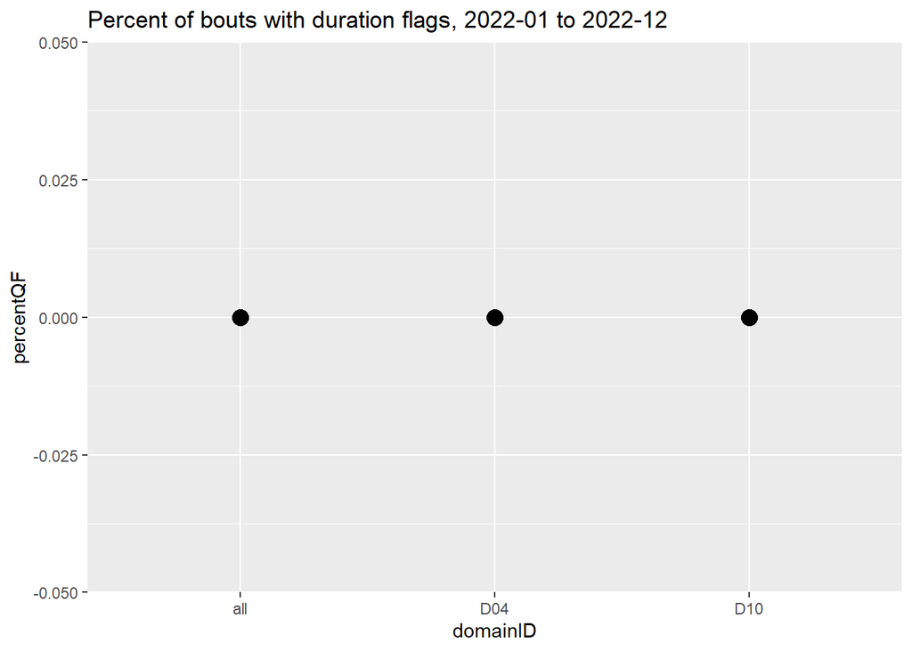

### FSP sample collection duration

Check that the length of time between the first and last FSP sample doesn’t exceed 30 days.

Examine the outputs. The first tab displays the dataset-wide summary of sites with sample duration issues. The second tab shows the flagged bouts, where duration is longer than the threshold specified in the function call. Lastly, check the figure that presents the summary table information graphically. If no issues in this report, 0% of bouts are flagged.

##### Summary

|  | tableName | dataSubset | domainID | siteID | totalCount | countQF | percentQF | dpID | dpName | functionName | outputType | minCheckedDate | maxCheckedDate | reportDate | qcMetrics | category | subsystem |
| --- | --- | --- | --- | --- | --- | --- | --- | --- | --- | --- | --- | --- | --- | --- | --- | --- | --- |
| 1 | fsp_sampleMetadata |  | all | allSites | 2 | 0 | 0 | DP1.30012.001 | Field spectral data | timely_bout_duration | summary | 2022-01 | 2022-12 | 2025-08-04 | True | timeliness | AOS |
| 2 | fsp_sampleMetadata |  | D04 | GUAN | 1 | 0 | 0 | DP1.30012.001 | Field spectral data | timely_bout_duration | summary | 2022-01 | 2022-12 | 2025-08-04 | True | timeliness | AOS |
| 3 | fsp_sampleMetadata |  | D10 | STER | 1 | 0 | 0 | DP1.30012.001 | Field spectral data | timely_bout_duration | summary | 2022-01 | 2022-12 | 2025-08-04 | True | timeliness | AOS |

##### Flags

```
## [1] "NO FLAGGED BOUTS, ALL FSP SAMPLES COLLECTED WITHIN 30 DAYS"
```

##### Figure

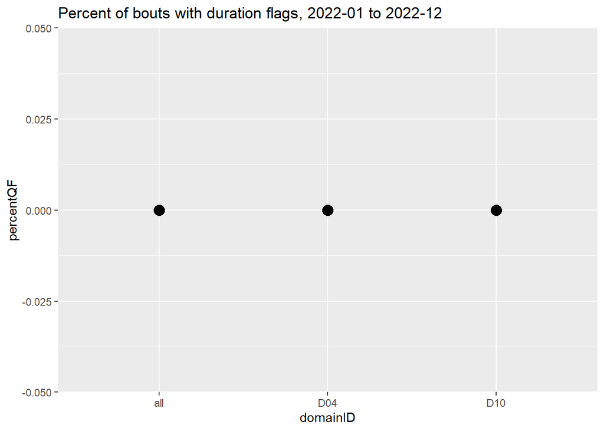

## Plausibility

### Duplicate checking

Run duplicate checking to identify and resolve duplicate records in the data. The `neonOS::removeDups()` function should be used to check for duplicates. Write the script so that if and when dups are found, it creates versions of the tables with duplicates removed for use with the bout and within-bout completeness functions. This will ensure that these metrics are not skewed. However, the report should print how many resolvable and unresolvable duplicates are found; if > 0, this requires follow-up actions outside of the QC script.

If checking data other than Portal data for duplicates (e.g., L0 or Fulcrum), the `neonOS::removeDups()` function will not work unless you format the input data to look like Portal data and have the required variables file. If that is too much effort and you are checking L0 data, there is a work-around where `restR2` can be used.

ONCE A CUSTOM SCRIPT IS DEVELOPED, THE TEXT IN THIS SECTION ABOVE THIS LINE CAN BE DELETED.

This section displays the results of duplicate checking performed earlier in the script. The `neonOS::removeDups()` function was used to identify and resolve duplicates in all FSP tables.

#### Summary

[output not shown]

### DP-specific plausibility checks

Add any additional code needed to conduct DP-specific checks related to plausibility. IF NONE ARE NEEDED, DELETE THIS SECTION. Make a subsection (####), with appropriate commentary for what is being checked, what results mean and how to follow up for each unique custom test that is needed.

Whenever possible, run custom code outputs through the `neonOSqc::format_custom_outputs()` function, which will produce an output list standardized to match the other generic `neonOSqc` functions. This is important so that results of custom tests can be summarized and aggregated for reporting purposes.

#### Spectral data quality checks

This section uses custom code to check spectral data quality, including reflectance range (0-1), wavelength range (300-2600), band count verification (426 bands expected), and spectral ratio validation. These checks ensure the spectral data meets expected quality standards.

```
## === PROCESSING SPECTRAL QUALITY CHECKS ===
```

##### Summary

|  | tableName | dataSubset | domainID | siteID | totalCount | countQF | percentQF | dpID | dpName | functionName | outputType | minCheckedDate | maxCheckedDate | reportDate | qcMetrics | category | subsystem |
| --- | --- | --- | --- | --- | --- | --- | --- | --- | --- | --- | --- | --- | --- | --- | --- | --- | --- |
| 1 | fsp_spectralData | spectral_data_quality | all | allSites | 64 | 0 | 0 | DP1.30012.001 | Field spectral data | custom_spectral_quality_check | summary | 2022-01 | 2022-12 | 2025-08-04 | True | plausibility | AOS |
| 2 | fsp_spectralData | spectral_data_quality | D04 | GUAN | 64 | 0 | 0 | DP1.30012.001 | Field spectral data | custom_spectral_quality_check | summary | 2022-01 | 2022-12 | 2025-08-04 | True | plausibility | AOS |

##### Flags

```
## [1] "NO SPECTRAL DATA QUALITY ISSUES FOUND"
```

## Outputs

```
## [1] "FSP QC outputs ready for GCS upload: 18 list outputs and 18 dataframe outputs"
```